# Actividad 3

### Héctor Hibran Tapia Fernández - A01661114

### Problem Statement

Continuing with the same scenario, now that you have been able to successfuly predict each student GPA, now you will classify each Student based on they probability to have a successful GPA score.

The different classes are:

- Low : Students where final GPA is predicted to be between: 0 and 2
- Medium : Students where final GPA is predicted to be between: 2 and 3.5
- High : Students where final GPA is predicted to be between: 3.5 and 5

### 1) Import Libraries

First let's import the following libraries, if there is any library that you need and is not in the list bellow feel free to include it

```python
import numpy as np
import pandas as pd
import matplotlib.pyplot as plt
import tensorflow as tf
from tensorflow.keras.models import Sequential
from tensorflow.keras.layers import Dense
from tensorflow.keras.layers import Dropout
from tensorflow.keras.layers import Conv1D, MaxPooling1D, Flatten
from tensorflow.keras.regularizers import l2
from sklearn.model_selection import train_test_split
from sklearn.preprocessing import StandardScaler, LabelEncoder
import seaborn as sns
```

### 2) Load Data

- You will use the same file from the previous activity (Student Performance Data)

```python
data = pd.read_csv("Student_performance_data _.csv")
data
```

|  | StudentID | Age | Gender | Ethnicity | ParentalEducation | StudyTimeWeekly | Absences | Tutoring | ParentalSupport | Extracurricular | Sports | Music | Volunteering | GPA | GradeClass |
| --- | --- | --- | --- | --- | --- | --- | --- | --- | --- | --- | --- | --- | --- | --- | --- |
| 0 | 1001 | 17 | 1 | 0 | 2 | 19.833723 | 7 | 1 | 2 | 0 | 0 | 1 | 0 | 2.929196 | 2.0 |
| 1 | 1002 | 18 | 0 | 0 | 1 | 15.408756 | 0 | 0 | 1 | 0 | 0 | 0 | 0 | 3.042915 | 1.0 |
| 2 | 1003 | 15 | 0 | 2 | 3 | 4.210570 | 26 | 0 | 2 | 0 | 0 | 0 | 0 | 0.112602 | 4.0 |
| 3 | 1004 | 17 | 1 | 0 | 3 | 10.028829 | 14 | 0 | 3 | 1 | 0 | 0 | 0 | 2.054218 | 3.0 |
| 4 | 1005 | 17 | 1 | 0 | 2 | 4.672495 | 17 | 1 | 3 | 0 | 0 | 0 | 0 | 1.288061 | 4.0 |
| ... | ... | ... | ... | ... | ... | ... | ... | ... | ... | ... | ... | ... | ... | ... | ... |
| 2387 | 3388 | 18 | 1 | 0 | 3 | 10.680555 | 2 | 0 | 4 | 1 | 0 | 0 | 0 | 3.455509 | 0.0 |
| 2388 | 3389 | 17 | 0 | 0 | 1 | 7.583217 | 4 | 1 | 4 | 0 | 1 | 0 | 0 | 3.279150 | 4.0 |
| 2389 | 3390 | 16 | 1 | 0 | 2 | 6.805500 | 20 | 0 | 2 | 0 | 0 | 0 | 1 | 1.142333 | 2.0 |
| 2390 | 3391 | 16 | 1 | 1 | 0 | 12.416653 | 17 | 0 | 2 | 0 | 1 | 1 | 0 | 1.803297 | 1.0 |
| 2391 | 3392 | 16 | 1 | 0 | 2 | 17.819907 | 13 | 0 | 2 | 0 | 0 | 0 | 1 | 2.140014 | 1.0 |

2392 rows × 15 columns

```python
data.info()
```

```
<class 'pandas.core.frame.DataFrame'>
RangeIndex: 2392 entries, 0 to 2391
Data columns (total 15 columns):
 #   Column             Non-Null Count  Dtype
---  ------             --------------  -----
 0   StudentID          2392 non-null   int64
 1   Age                2392 non-null   int64
 2   Gender             2392 non-null   int64
 3   Ethnicity          2392 non-null   int64
 4   ParentalEducation  2392 non-null   int64
 5   StudyTimeWeekly    2392 non-null   float64
 6   Absences           2392 non-null   int64
 7   Tutoring           2392 non-null   int64
 8   ParentalSupport    2392 non-null   int64
 9   Extracurricular    2392 non-null   int64
 10  Sports             2392 non-null   int64
 11  Music              2392 non-null   int64
 12  Volunteering       2392 non-null   int64
 13  GPA                2392 non-null   float64
 14  GradeClass         2392 non-null   float64
dtypes: float64(3), int64(12)
memory usage: 280.4 KB
```

### 3) Add a new column called 'Profile' this column will have the following information

Based on the value of GPA for each student:

- If GPA values between 0 and 2 will be labeled 'Low',
- Values between 2 and 3.5 will be 'Medium',
- And values between 3.5 and 5 will be 'High'.

```python
data['Profile'] = pd.cut(data['GPA'], bins=[0, 2, 3.5, 5], labels=['Low', 'Medium', 'High'])
data.head(10)
```

|  | StudentID | Age | Gender | Ethnicity | ParentalEducation | StudyTimeWeekly | Absences | Tutoring | ParentalSupport | Extracurricular | Sports | Music | Volunteering | GPA | GradeClass | Profile |
| --- | --- | --- | --- | --- | --- | --- | --- | --- | --- | --- | --- | --- | --- | --- | --- | --- |
| 0 | 1001 | 17 | 1 | 0 | 2 | 19.833723 | 7 | 1 | 2 | 0 | 0 | 1 | 0 | 2.929196 | 2.0 | Medium |
| 1 | 1002 | 18 | 0 | 0 | 1 | 15.408756 | 0 | 0 | 1 | 0 | 0 | 0 | 0 | 3.042915 | 1.0 | Medium |
| 2 | 1003 | 15 | 0 | 2 | 3 | 4.210570 | 26 | 0 | 2 | 0 | 0 | 0 | 0 | 0.112602 | 4.0 | Low |
| 3 | 1004 | 17 | 1 | 0 | 3 | 10.028829 | 14 | 0 | 3 | 1 | 0 | 0 | 0 | 2.054218 | 3.0 | Medium |
| 4 | 1005 | 17 | 1 | 0 | 2 | 4.672495 | 17 | 1 | 3 | 0 | 0 | 0 | 0 | 1.288061 | 4.0 | Low |
| 5 | 1006 | 18 | 0 | 0 | 1 | 8.191219 | 0 | 0 | 1 | 1 | 0 | 0 | 0 | 3.084184 | 1.0 | Medium |
| 6 | 1007 | 15 | 0 | 1 | 1 | 15.601680 | 10 | 0 | 3 | 0 | 1 | 0 | 0 | 2.748237 | 2.0 | Medium |
| 7 | 1008 | 15 | 1 | 1 | 4 | 15.424496 | 22 | 1 | 1 | 1 | 0 | 0 | 0 | 1.360143 | 4.0 | Low |
| 8 | 1009 | 17 | 0 | 0 | 0 | 4.562008 | 1 | 0 | 2 | 0 | 1 | 0 | 1 | 2.896819 | 2.0 | Medium |
| 9 | 1010 | 16 | 1 | 0 | 1 | 18.444466 | 0 | 0 | 3 | 1 | 0 | 0 | 0 | 3.573474 | 0.0 | High |

### 4) Use Matplotlib to show a Pie chart to show the percentage of students in each profile.

- Title: Students distribution of Profiles
- Graph Type: pie

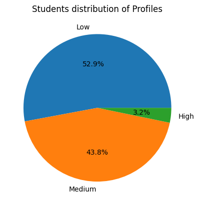

```python
profile_counts = data['Profile'].value_counts()
plt.pie(profile_counts, labels = profile_counts.index, autopct='%1.1f%%')
plt.title('Students distribution of Profiles')
plt.show()
```

### 5) Convert the Profile column into a Categorical Int

You have already created a column with three different values: 'Low', 'Medium', 'High'. These are Categorical values. But, it is important to notice that Neural Networks works better with numbers, since we apply mathematical operations to them.

Next you need to convert Profile values from Low, Medium and High, to 0, 1 and 2. IMPORTANT, the order does not matter, but make sure you always assign the same number to Low, same number to Medium and same number to High.

Make sure to use the fit_transform method from LabelEncoder.

De esta forma no porque ordena Medium = 2, Low = 1 y High = 0. Necesitamos ordenarlos en orden para que tengan sentido.

```python
# label_encoder = LabelEncoder()
# data['Profile'] = label_encoder.fit_transform(data['Profile'])
# data.head(10)
```

```python
data['Profile'].fillna('Low', inplace=True) # Rellenamos NAN's porque tiene.
```

```python
from sklearn.preprocessing import LabelEncoder

# Cambiamos temporalmente los valores para que LabelEncoder los ordene correctamente
data['Profile'] = data['Profile'].replace({'High': 'A', 'Medium': 'B', 'Low': 'C'})

label_encoder = LabelEncoder()
data['Profile'] = label_encoder.fit_transform(data['Profile'])
data['Profile'] = data['Profile'].replace({0: 2, 1: 1, 2: 0}) # Invertimos los valores para que se ajusten a 2 (High), 1 (Medium), 0 (Low)

data.head(10)
```

|  | StudentID | Age | Gender | Ethnicity | ParentalEducation | StudyTimeWeekly | Absences | Tutoring | ParentalSupport | Extracurricular | Sports | Music | Volunteering | GPA | GradeClass | Profile |
| --- | --- | --- | --- | --- | --- | --- | --- | --- | --- | --- | --- | --- | --- | --- | --- | --- |
| 0 | 1001 | 17 | 1 | 0 | 2 | 19.833723 | 7 | 1 | 2 | 0 | 0 | 1 | 0 | 2.929196 | 2.0 | 1 |
| 1 | 1002 | 18 | 0 | 0 | 1 | 15.408756 | 0 | 0 | 1 | 0 | 0 | 0 | 0 | 3.042915 | 1.0 | 1 |
| 2 | 1003 | 15 | 0 | 2 | 3 | 4.210570 | 26 | 0 | 2 | 0 | 0 | 0 | 0 | 0.112602 | 4.0 | 0 |
| 3 | 1004 | 17 | 1 | 0 | 3 | 10.028829 | 14 | 0 | 3 | 1 | 0 | 0 | 0 | 2.054218 | 3.0 | 1 |
| 4 | 1005 | 17 | 1 | 0 | 2 | 4.672495 | 17 | 1 | 3 | 0 | 0 | 0 | 0 | 1.288061 | 4.0 | 0 |
| 5 | 1006 | 18 | 0 | 0 | 1 | 8.191219 | 0 | 0 | 1 | 1 | 0 | 0 | 0 | 3.084184 | 1.0 | 1 |
| 6 | 1007 | 15 | 0 | 1 | 1 | 15.601680 | 10 | 0 | 3 | 0 | 1 | 0 | 0 | 2.748237 | 2.0 | 1 |
| 7 | 1008 | 15 | 1 | 1 | 4 | 15.424496 | 22 | 1 | 1 | 1 | 0 | 0 | 0 | 1.360143 | 4.0 | 0 |
| 8 | 1009 | 17 | 0 | 0 | 0 | 4.562008 | 1 | 0 | 2 | 0 | 1 | 0 | 1 | 2.896819 | 2.0 | 1 |
| 9 | 1010 | 16 | 1 | 0 | 1 | 18.444466 | 0 | 0 | 3 | 1 | 0 | 0 | 0 | 3.573474 | 0.0 | 2 |

### 6) Select the columns for your model.

Same as the last excersice we need a dataset for features and a dataset for label.

- Create the following dataset:
  - A dataset with the columns for the model.
  - From that data set generate the 'X' dataset. This dataset will have all the features (make sure Profile is NOT in this dataset)
  - Generate a second 'y' dataset, This dataset will only have our label column, which is 'Profile'.
  - Generate the Train and Test datasets for each X and y:
    - X_train with 80% of the data
    - X_test with 20% of the data
    - y_train with 80% of the data
    - y_test with 20% of the data

```python
X = data.drop(columns=['Profile'])
y = data['Profile']
```

```python
X_train, X_test, y_train, y_test = train_test_split(X, y, test_size=0.2, random_state=42)
```

### 7) All Feature datasets in the same scale.

Use StandardScaler to make sure all features in the X_train and X_test datasets are on the same scale.

Standardization transforms your data so that it has a mean of 0 and a standard deviation of 1. This is important because many machine learning algorithms perform better when the input features are on a similar scale.

Reason for Using StandardScaler:

- Consistent Scale: Features with different scales (e.g., age in years, income in dollars) can bias the model. StandardScaler ensures all features contribute equally.
- Improved Convergence: Algorithms like gradient descent converge faster with standardized data.
- Regularization: Helps in achieving better performance in regularization methods like Ridge and Lasso regression.

```python
scaler = StandardScaler()
X_train = scaler.fit_transform(X_train)
X_test = scaler.transform(X_test)
```

### 8. Define your Deep Neural Network.

- This will be a Sequential Neural Network.
- With a Dense input layer with 64 units, and input dimention based on the X_train size and Relu as the activation function.
- A Dense hidden layer with 32 units, and Relu as the activation function.
- And a Dense output layer with the number of different values in the y dataset, activation function = to sofmax

This last part of the output layer is super important, since we want to do a classification and not a regression, we will use activation functions that fits better a classification scenario.

```python
model = Sequential()
model.add(Dense(64, input_dim=X_train.shape[1], activation='relu'))
model.add(Dense(32, activation='relu'))
model.add(Dense(3, activation='softmax'))
```

### 9. Compile your Neural Network

- Choose Adam as the optimizer
- And sparse_categorical_crossentropy as the Loss function
- Also add the following metrics: accuracy

```python
model.compile(optimizer='adam', loss='sparse_categorical_crossentropy', metrics=['accuracy'])
```

### 10. Fit (or train) your model

- Use the X_train and y_train datasets for the training
- Do 50 data iterations
- Choose the batch size = 10
- Also select a validation_split of 0.2
- Save the result of the fit function in a variable called 'history'

```python
history = model.fit(X_train, y_train, epochs=50, batch_size=10, validation_split=0.2)
```

```
153/153 ━━━━━━━━━━━━━━━━━━━━ 5s 8ms/step - accuracy: 0.6518 - loss: 0.7863 - val_accuracy: 0.9347 - val_loss: 0.2546
153/153 ━━━━━━━━━━━━━━━━━━━━ 1s 5ms/step - accuracy: 0.9350 - loss: 0.2423 - val_accuracy: 0.9478 - val_loss: 0.1512
153/153 ━━━━━━━━━━━━━━━━━━━━ 1s 4ms/step - accuracy: 0.9514 - loss: 0.1536 - val_accuracy: 0.9582 - val_loss: 0.1146
153/153 ━━━━━━━━━━━━━━━━━━━━ 1s 5ms/step - accuracy: 0.9660 - loss: 0.1008 - val_accuracy: 0.9582 - val_loss: 0.0966
153/153 ━━━━━━━━━━━━━━━━━━━━ 1s 5ms/step - accuracy: 0.9778 - loss: 0.0818 - val_accuracy: 0.9634 - val_loss: 0.0874
153/153 ━━━━━━━━━━━━━━━━━━━━ 1s 4ms/step - accuracy: 0.9829 - loss: 0.0598 - val_accuracy: 0.9661 - val_loss: 0.0734
153/153 ━━━━━━━━━━━━━━━━━━━━ 1s 6ms/step - accuracy: 0.9844 - loss: 0.0532 - val_accuracy: 0.9765 - val_loss: 0.0660
153/153 ━━━━━━━━━━━━━━━━━━━━ 1s 4ms/step - accuracy: 0.9944 - loss: 0.0366 - val_accuracy: 0.9765 - val_loss: 0.0606
153/153 ━━━━━━━━━━━━━━━━━━━━ 1s 6ms/step - accuracy: 0.9886 - loss: 0.0433 - val_accuracy: 0.9791 - val_loss: 0.0578
153/153 ━━━━━━━━━━━━━━━━━━━━ 2s 10ms/step - accuracy: 0.9953 - loss: 0.0275 - val_accuracy: 0.9843 - val_loss: 0.0470
153/153 ━━━━━━━━━━━━━━━━━━━━ 2s 8ms/step - accuracy: 0.9947 - loss: 0.0275 - val_accuracy: 0.9843 - val_loss: 0.0490
153/153 ━━━━━━━━━━━━━━━━━━━━ 2s 4ms/step - accuracy: 0.9924 - loss: 0.0249 - val_accuracy: 0.9765 - val_loss: 0.0495
153/153 ━━━━━━━━━━━━━━━━━━━━ 1s 2ms/step - accuracy: 0.9943 - loss: 0.0212 - val_accuracy: 0.9791 - val_loss: 0.0392
153/153 ━━━━━━━━━━━━━━━━━━━━ 1s 2ms/step - accuracy: 0.9952 - loss: 0.0174 - val_accuracy: 0.9765 - val_loss: 0.0456
153/153 ━━━━━━━━━━━━━━━━━━━━ 1s 2ms/step - accuracy: 0.9990 - loss: 0.0127 - val_accuracy: 0.9869 - val_loss: 0.0353
153/153 ━━━━━━━━━━━━━━━━━━━━ 0s 2ms/step - accuracy: 0.9975 - loss: 0.0170 - val_accuracy: 0.9791 - val_loss: 0.0394
153/153 ━━━━━━━━━━━━━━━━━━━━ 1s 2ms/step - accuracy: 0.9984 - loss: 0.0104 - val_accuracy: 0.9791 - val_loss: 0.0413
153/153 ━━━━━━━━━━━━━━━━━━━━ 1s 2ms/step - accuracy: 0.9979 - loss: 0.0140 - val_accuracy: 0.9843 - val_loss: 0.0416
153/153 ━━━━━━━━━━━━━━━━━━━━ 0s 2ms/step - accuracy: 0.9999 - loss: 0.0066 - val_accuracy: 0.9843 - val_loss: 0.0399
153/153 ━━━━━━━━━━━━━━━━━━━━ 1s 2ms/step - accuracy: 0.9982 - loss: 0.0084 - val_accuracy: 0.9791 - val_loss: 0.0355
153/153 ━━━━━━━━━━━━━━━━━━━━ 1s 2ms/step - accuracy: 0.9989 - loss: 0.0062 - val_accuracy: 0.9843 - val_loss: 0.0323
153/153 ━━━━━━━━━━━━━━━━━━━━ 1s 2ms/step - accuracy: 1.0000 - loss: 0.0040 - val_accuracy: 0.9817 - val_loss: 0.0352
153/153 ━━━━━━━━━━━━━━━━━━━━ 1s 2ms/step - accuracy: 1.0000 - loss: 0.0053 - val_accuracy: 0.9843 - val_loss: 0.0383
153/153 ━━━━━━━━━━━━━━━━━━━━ 1s 2ms/step - accuracy: 1.0000 - loss: 0.0034 - val_accuracy: 0.9869 - val_loss: 0.0314
153/153 ━━━━━━━━━━━━━━━━━━━━ 0s 2ms/step - accuracy: 1.0000 - loss: 0.0029 - val_accuracy: 0.9869 - val_loss: 0.0276
153/153 ━━━━━━━━━━━━━━━━━━━━ 1s 4ms/step - accuracy: 1.0000 - loss: 0.0024 - val_accuracy: 0.9817 - val_loss: 0.0316
153/153 ━━━━━━━━━━━━━━━━━━━━ 1s 4ms/step - accuracy: 1.0000 - loss: 0.0021 - val_accuracy: 0.9869 - val_loss: 0.0246
153/153 ━━━━━━━━━━━━━━━━━━━━ 1s 4ms/step - accuracy: 1.0000 - loss: 0.0022 - val_accuracy: 0.9869 - val_loss: 0.0258
153/153 ━━━━━━━━━━━━━━━━━━━━ 1s 3ms/step - accuracy: 1.0000 - loss: 0.0016 - val_accuracy: 0.9817 - val_loss: 0.0300
153/153 ━━━━━━━━━━━━━━━━━━━━ 1s 4ms/step - accuracy: 1.0000 - loss: 0.0016 - val_accuracy: 0.9843 - val_loss: 0.0277
153/153 ━━━━━━━━━━━━━━━━━━━━ 1s 3ms/step - accuracy: 1.0000 - loss: 0.0015 - val_accuracy: 0.9869 - val_loss: 0.0262
153/153 ━━━━━━━━━━━━━━━━━━━━ 0s 2ms/step - accuracy: 1.0000 - loss: 0.0013 - val_accuracy: 0.9869 - val_loss: 0.0261
153/153 ━━━━━━━━━━━━━━━━━━━━ 1s 2ms/step - accuracy: 1.0000 - loss: 0.0012 - val_accuracy: 0.9896 - val_loss: 0.0216
153/153 ━━━━━━━━━━━━━━━━━━━━ 1s 2ms/step - accuracy: 1.0000 - loss: 7.5082e-04 - val_accuracy: 0.9869 - val_loss: 0.0244
153/153 ━━━━━━━━━━━━━━━━━━━━ 1s 2ms/step - accuracy: 1.0000 - loss: 7.3061e-04 - val_accuracy: 0.9843 - val_loss: 0.0259
153/153 ━━━━━━━━━━━━━━━━━━━━ 1s 2ms/step - accuracy: 1.0000 - loss: 7.2907e-04 - val_accuracy: 0.9869 - val_loss: 0.0227
153/153 ━━━━━━━━━━━━━━━━━━━━ 1s 2ms/step - accuracy: 1.0000 - loss: 6.7892e-04 - val_accuracy: 0.9843 - val_loss: 0.0279
153/153 ━━━━━━━━━━━━━━━━━━━━ 0s 2ms/step - accuracy: 1.0000 - loss: 6.4772e-04 - val_accuracy: 0.9843 - val_loss: 0.0227
153/153 ━━━━━━━━━━━━━━━━━━━━ 0s 2ms/step - accuracy: 1.0000 - loss: 5.3562e-04 - val_accuracy: 0.9896 - val_loss: 0.0231
153/153 ━━━━━━━━━━━━━━━━━━━━ 1s 2ms/step - accuracy: 1.0000 - loss: 5.4926e-04 - val_accuracy: 0.9896 - val_loss: 0.0219
153/153 ━━━━━━━━━━━━━━━━━━━━ 0s 2ms/step - accuracy: 1.0000 - loss: 3.5089e-04 - val_accuracy: 0.9869 - val_loss: 0.0223
153/153 ━━━━━━━━━━━━━━━━━━━━ 1s 2ms/step - accuracy: 1.0000 - loss: 3.9777e-04 - val_accuracy: 0.9896 - val_loss: 0.0221
153/153 ━━━━━━━━━━━━━━━━━━━━ 1s 2ms/step - accuracy: 1.0000 - loss: 4.1955e-04 - val_accuracy: 0.9869 - val_loss: 0.0246
153/153 ━━━━━━━━━━━━━━━━━━━━ 1s 2ms/step - accuracy: 1.0000 - loss: 4.1149e-04 - val_accuracy: 0.9869 - val_loss: 0.0216
153/153 ━━━━━━━━━━━━━━━━━━━━ 0s 2ms/step - accuracy: 1.0000 - loss: 2.4891e-04 - val_accuracy: 0.9869 - val_loss: 0.0240
153/153 ━━━━━━━━━━━━━━━━━━━━ 1s 2ms/step - accuracy: 1.0000 - loss: 2.3799e-04 - val_accuracy: 0.9869 - val_loss: 0.0231
153/153 ━━━━━━━━━━━━━━━━━━━━ 0s 2ms/step - accuracy: 1.0000 - loss: 2.8716e-04 - val_accuracy: 0.9896 - val_loss: 0.0218
153/153 ━━━━━━━━━━━━━━━━━━━━ 0s 2ms/step - accuracy: 1.0000 - loss: 2.0294e-04 - val_accuracy: 0.9896 - val_loss: 0.0220
153/153 ━━━━━━━━━━━━━━━━━━━━ 1s 2ms/step - accuracy: 1.0000 - loss: 2.0947e-04 - val_accuracy: 0.9869 - val_loss: 0.0254
153/153 ━━━━━━━━━━━━━━━━━━━━ 0s 2ms/step - accuracy: 1.0000 - loss: 1.8232e-04 - val_accuracy: 0.9869 - val_loss: 0.0234
```

### 11. View your history variable:

- Use Matplotlib.pyplot to show graphs of your model traning history
- In one graph:
  - Plot the Training Accuracy and the Validation Accuracy
  - X Label = Epochs
  - Y Label = Accuracy
  - Title = Model Accuracy over Epochs
- In a second graph:
  - Plot the Training Loss and the Validation Loss
  - X Label = Epochs
  - Y Label = Loss
  - Title = Model Loss over Epochs

```python
history_dict = history.history
accuracy = history_dict['accuracy']
val_accuracy = history_dict['val_accuracy']
loss = history_dict['loss']
val_loss = history_dict['val_loss']
epochs = range(1, len(accuracy) + 1)
```

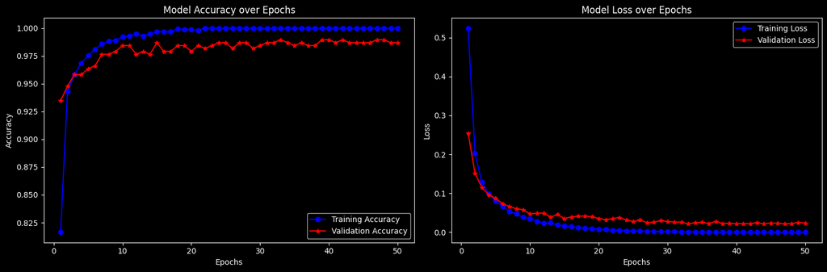

```python
plt.style.use('dark_background')

fig, (ax1, ax2) = plt.subplots(1, 2, figsize=(15, 5))
ax1.plot(epochs, accuracy, 'bo-', label='Training Accuracy')
ax1.plot(epochs, val_accuracy, 'r*-', label='Validation Accuracy')
ax1.set_title('Model Accuracy over Epochs')
ax1.set_xlabel('Epochs')
ax1.set_ylabel('Accuracy')
ax1.legend()

ax2.plot(epochs, loss, 'bo-', label='Training Loss')
ax2.plot(epochs, val_loss, 'r*-', label='Validation Loss')
ax2.set_title('Model Loss over Epochs')
ax2.set_xlabel('Epochs')
ax2.set_ylabel('Loss')
ax2.legend()

plt.tight_layout()
plt.show()
```

### 12. Evaluate your model:

- See the result of your loss function.
- What can you deduct from there?

**Model Accuracy over Epochs**

- Linea Azul: Precisión del entrenamiento durante las epocas se ve que el se estabiliza al rededor del 1.0, lo que nos dice que alcanzó una presición casi perfecta.
- Linea Roja: Precisión de la validación se nota que durante las primeras 10 épocas aprende normal el modelo, pero después se notan como fluctua la línea, puede ser un leve sobreajuste.

### 13. Use your model to make some predictions:

- Make predictions of your X_test dataset
- Print the each of the predictions and the actual value (which is in y_test)
- Replace the 'Low', 'Medium' and 'High' to your actual and predicted values.
- How good was your model?

```python
predictions = model.predict(X_test)
predicted_classes = np.argmax(predictions, axis=1)
label_mapping = {0: 'Low', 1: 'Medium', 2: 'High'}

predicted_labels = [label_mapping[label] for label in predicted_classes]
actual_labels = [label_mapping[label] for label in y_test]

print("Predictions vs Actual Values:")
for i in range(len(predicted_labels)):
    print(f"Predicted: {predicted_labels[i]}, Actual: {actual_labels[i]}")
```

```
15/15 ━━━━━━━━━━━━━━━━━━━━ 0s 29ms/step
Predictions vs Actual Values:
Predicted: Low, Actual: Low
Predicted: Medium, Actual: Medium
Predicted: Medium, Actual: Medium
Predicted: High, Actual: High
Predicted: Low, Actual: Low
Predicted: Medium, Actual: Medium
Predicted: Medium, Actual: Medium
Predicted: Medium, Actual: Medium
Predicted: Medium, Actual: Medium
Predicted: Low, Actual: Low
Predicted: Medium, Actual: Medium
Predicted: Low, Actual: Low
Predicted: Medium, Actual: Medium
Predicted: Medium, Actual: Medium
Predicted: Medium, Actual: Medium
Predicted: Low, Actual: Low
Predicted: Low, Actual: Low
Predicted: Low, Actual: Low
Predicted: Medium, Actual: Medium
Predicted: Medium, Actual: Medium
Predicted: Low, Actual: Low
Predicted: Low, Actual: Low
Predicted: Low, Actual: Low
Predicted: Medium, Actual: Medium
Predicted: Low, Actual: Low
Predicted: Low, Actual: Low
Predicted: Low, Actual: Low
Predicted: Medium, Actual: Medium
Predicted: Medium, Actual: Medium
Predicted: Medium, Actual: Medium
Predicted: Medium, Actual: Medium
Predicted: Low, Actual: Low
Predicted: Medium, Actual: Medium
Predicted: Medium, Actual: Medium
Predicted: Low, Actual: Low
Predicted: Low, Actual: Low
Predicted: Medium, Actual: Medium
Predicted: Medium, Actual: Medium
```

[output cut: 426 more lines]

```
Predicted: Medium, Actual: Medium
Predicted: Low, Actual: Low
Predicted: Low, Actual: Low
Predicted: Medium, Actual: Medium
Predicted: Medium, Actual: Medium
Predicted: Medium, Actual: Medium
Predicted: Low, Actual: Low
Predicted: Medium, Actual: Medium
Predicted: Low, Actual: Low
Predicted: Low, Actual: Low
Predicted: Low, Actual: Low
Predicted: Medium, Actual: Medium
Predicted: Medium, Actual: Medium
Predicted: Medium, Actual: Medium
Predicted: Low, Actual: Low
```

```python
from sklearn.metrics import accuracy_score, classification_report, confusion_matrix

accuracy = accuracy_score(y_test, predicted_classes)
print(f"\nModel Accuracy on Test Data: {accuracy:.2f}")
print("\nClassification Report:")
print(classification_report(y_test, predicted_classes, target_names=['Low', 'Medium', 'High']))
print("Confusion Matrix:")
print(confusion_matrix(y_test, predicted_classes))
```

```
Model Accuracy on Test Data: 0.98

Classification Report:
              precision    recall  f1-score   support

         Low       1.00      0.99      1.00       249
      Medium       0.97      1.00      0.98       214
        High       0.92      0.69      0.79        16

    accuracy                           0.98       479
   macro avg       0.96      0.89      0.92       479
weighted avg       0.98      0.98      0.98       479

Confusion Matrix:
[[247   2   0]
 [  0 213   1]
 [  0   5  11]]
```

### 14. Compete against this model:

- Create two more different models to compete with this model
- Here are a few ideas of things you can change:
  - During Dataset data engineering:
    - You can remove features that you think do not help in the training and prediction
    - Feature Scaling: Ensure all features are on a similar scale (as you already did with StandardScaler)
  - During Model Definition:
    - You can change the Model Architecture (change the type or number of layers or the number of units)
    - You can add dropout layers to prevent overfitting
  - During Model Compile:
    - You can try other optimizer when compiling your model, here some optimizer samples: Adam, RMSprop, or Adagrad.
    - Try another Loss Function
  - During Model Training:
    - Encrease the number of Epochs
    - Adjust the size of your batch
- Explain in a Markdown cell which changes are you implementing
- Show the comparison of your model versus the original model

#### Model 2:

```
306/306 ━━━━━━━━━━━━━━━━━━━━ 2s 4ms/step - accuracy: 0.8297 - loss: 0.4817 - val_accuracy: 0.9373 - val_loss: 0.1798
306/306 ━━━━━━━━━━━━━━━━━━━━ 1s 2ms/step - accuracy: 0.9551 - loss: 0.1386 - val_accuracy: 0.9582 - val_loss: 0.1225
306/306 ━━━━━━━━━━━━━━━━━━━━ 1s 2ms/step - accuracy: 0.9589 - loss: 0.1289 - val_accuracy: 0.9504 - val_loss: 0.1236
306/306 ━━━━━━━━━━━━━━━━━━━━ 1s 2ms/step - accuracy: 0.9531 - loss: 0.1312 - val_accuracy: 0.9582 - val_loss: 0.1476
306/306 ━━━━━━━━━━━━━━━━━━━━ 1s 2ms/step - accuracy: 0.9660 - loss: 0.1060 - val_accuracy: 0.9791 - val_loss: 0.0807
306/306 ━━━━━━━━━━━━━━━━━━━━ 1s 2ms/step - accuracy: 0.9733 - loss: 0.0741 - val_accuracy: 0.9661 - val_loss: 0.0856
306/306 ━━━━━━━━━━━━━━━━━━━━ 1s 2ms/step - accuracy: 0.9720 - loss: 0.0846 - val_accuracy: 0.9661 - val_loss: 0.0943
306/306 ━━━━━━━━━━━━━━━━━━━━ 1s 2ms/step - accuracy: 0.9705 - loss: 0.0822 - val_accuracy: 0.9582 - val_loss: 0.1035
306/306 ━━━━━━━━━━━━━━━━━━━━ 1s 2ms/step - accuracy: 0.9728 - loss: 0.0645 - val_accuracy: 0.9661 - val_loss: 0.1375
306/306 ━━━━━━━━━━━━━━━━━━━━ 1s 2ms/step - accuracy: 0.9786 - loss: 0.0658 - val_accuracy: 0.9713 - val_loss: 0.1068
306/306 ━━━━━━━━━━━━━━━━━━━━ 2s 3ms/step - accuracy: 0.9812 - loss: 0.0530 - val_accuracy: 0.9765 - val_loss: 0.0807
306/306 ━━━━━━━━━━━━━━━━━━━━ 1s 3ms/step - accuracy: 0.9804 - loss: 0.0599 - val_accuracy: 0.9922 - val_loss: 0.0580
306/306 ━━━━━━━━━━━━━━━━━━━━ 1s 2ms/step - accuracy: 0.9802 - loss: 0.0547 - val_accuracy: 0.9713 - val_loss: 0.0913
306/306 ━━━━━━━━━━━━━━━━━━━━ 1s 2ms/step - accuracy: 0.9838 - loss: 0.0467 - val_accuracy: 0.9843 - val_loss: 0.0712
306/306 ━━━━━━━━━━━━━━━━━━━━ 1s 2ms/step - accuracy: 0.9778 - loss: 0.0543 - val_accuracy: 0.9634 - val_loss: 0.1469
306/306 ━━━━━━━━━━━━━━━━━━━━ 1s 2ms/step - accuracy: 0.9736 - loss: 0.1025 - val_accuracy: 0.9817 - val_loss: 0.0730
306/306 ━━━━━━━━━━━━━━━━━━━━ 1s 2ms/step - accuracy: 0.9795 - loss: 0.0674 - val_accuracy: 0.9896 - val_loss: 0.0626
306/306 ━━━━━━━━━━━━━━━━━━━━ 1s 2ms/step - accuracy: 0.9872 - loss: 0.0458 - val_accuracy: 0.9817 - val_loss: 0.0599
306/306 ━━━━━━━━━━━━━━━━━━━━ 1s 2ms/step - accuracy: 0.9847 - loss: 0.0612 - val_accuracy: 0.9634 - val_loss: 0.0910
306/306 ━━━━━━━━━━━━━━━━━━━━ 1s 2ms/step - accuracy: 0.9817 - loss: 0.0593 - val_accuracy: 0.9817 - val_loss: 0.0683
306/306 ━━━━━━━━━━━━━━━━━━━━ 1s 2ms/step - accuracy: 0.9872 - loss: 0.0389 - val_accuracy: 0.9661 - val_loss: 0.0706
306/306 ━━━━━━━━━━━━━━━━━━━━ 1s 2ms/step - accuracy: 0.9919 - loss: 0.0353 - val_accuracy: 0.9739 - val_loss: 0.0941
306/306 ━━━━━━━━━━━━━━━━━━━━ 1s 2ms/step - accuracy: 0.9889 - loss: 0.0300 - val_accuracy: 0.9530 - val_loss: 0.0981
306/306 ━━━━━━━━━━━━━━━━━━━━ 1s 3ms/step - accuracy: 0.9820 - loss: 0.0551 - val_accuracy: 0.9869 - val_loss: 0.0685
306/306 ━━━━━━━━━━━━━━━━━━━━ 1s 3ms/step - accuracy: 0.9860 - loss: 0.0634 - val_accuracy: 0.9896 - val_loss: 0.0594
306/306 ━━━━━━━━━━━━━━━━━━━━ 1s 3ms/step - accuracy: 0.9891 - loss: 0.0347 - val_accuracy: 0.9817 - val_loss: 0.0860
306/306 ━━━━━━━━━━━━━━━━━━━━ 1s 2ms/step - accuracy: 0.9845 - loss: 0.0488 - val_accuracy: 0.9869 - val_loss: 0.0641
306/306 ━━━━━━━━━━━━━━━━━━━━ 1s 2ms/step - accuracy: 0.9916 - loss: 0.0251 - val_accuracy: 0.9869 - val_loss: 0.0548
306/306 ━━━━━━━━━━━━━━━━━━━━ 1s 2ms/step - accuracy: 0.9852 - loss: 0.0634 - val_accuracy: 0.9843 - val_loss: 0.0565
306/306 ━━━━━━━━━━━━━━━━━━━━ 1s 2ms/step - accuracy: 0.9850 - loss: 0.0508 - val_accuracy: 0.9791 - val_loss: 0.0706
306/306 ━━━━━━━━━━━━━━━━━━━━ 1s 2ms/step - accuracy: 0.9891 - loss: 0.0321 - val_accuracy: 0.9739 - val_loss: 0.0658
306/306 ━━━━━━━━━━━━━━━━━━━━ 1s 2ms/step - accuracy: 0.9869 - loss: 0.0395 - val_accuracy: 0.9817 - val_loss: 0.0916
306/306 ━━━━━━━━━━━━━━━━━━━━ 1s 2ms/step - accuracy: 0.9795 - loss: 0.0722 - val_accuracy: 0.9687 - val_loss: 0.1250
306/306 ━━━━━━━━━━━━━━━━━━━━ 1s 2ms/step - accuracy: 0.9834 - loss: 0.0726 - val_accuracy: 0.9817 - val_loss: 0.0625
306/306 ━━━━━━━━━━━━━━━━━━━━ 1s 2ms/step - accuracy: 0.9907 - loss: 0.0330 - val_accuracy: 0.9817 - val_loss: 0.0604
306/306 ━━━━━━━━━━━━━━━━━━━━ 2s 3ms/step - accuracy: 0.9836 - loss: 0.0401 - val_accuracy: 0.9791 - val_loss: 0.0445
306/306 ━━━━━━━━━━━━━━━━━━━━ 1s 3ms/step - accuracy: 0.9879 - loss: 0.0547 - val_accuracy: 0.9817 - val_loss: 0.0624
306/306 ━━━━━━━━━━━━━━━━━━━━ 1s 3ms/step - accuracy: 0.9881 - loss: 0.0385 - val_accuracy: 0.9661 - val_loss: 0.0933
306/306 ━━━━━━━━━━━━━━━━━━━━ 1s 2ms/step - accuracy: 0.9871 - loss: 0.0383 - val_accuracy: 0.9843 - val_loss: 0.0655
306/306 ━━━━━━━━━━━━━━━━━━━━ 1s 2ms/step - accuracy: 0.9840 - loss: 0.0375 - val_accuracy: 0.9843 - val_loss: 0.0420
```

[output cut: 45 more lines]

```
306/306 ━━━━━━━━━━━━━━━━━━━━ 1s 2ms/step - accuracy: 0.9905 - loss: 0.0434 - val_accuracy: 0.9922 - val_loss: 0.0403
306/306 ━━━━━━━━━━━━━━━━━━━━ 1s 2ms/step - accuracy: 0.9913 - loss: 0.0205 - val_accuracy: 0.9869 - val_loss: 0.0628
306/306 ━━━━━━━━━━━━━━━━━━━━ 1s 3ms/step - accuracy: 0.9928 - loss: 0.0265 - val_accuracy: 0.9896 - val_loss: 0.0946
306/306 ━━━━━━━━━━━━━━━━━━━━ 2s 4ms/step - accuracy: 0.9970 - loss: 0.0127 - val_accuracy: 0.9869 - val_loss: 0.0959
306/306 ━━━━━━━━━━━━━━━━━━━━ 1s 3ms/step - accuracy: 0.9913 - loss: 0.0432 - val_accuracy: 0.9922 - val_loss: 0.0559
306/306 ━━━━━━━━━━━━━━━━━━━━ 1s 2ms/step - accuracy: 0.9938 - loss: 0.0227 - val_accuracy: 0.9896 - val_loss: 0.0627
306/306 ━━━━━━━━━━━━━━━━━━━━ 1s 2ms/step - accuracy: 0.9917 - loss: 0.0330 - val_accuracy: 0.9922 - val_loss: 0.0634
306/306 ━━━━━━━━━━━━━━━━━━━━ 1s 2ms/step - accuracy: 0.9917 - loss: 0.0354 - val_accuracy: 0.9896 - val_loss: 0.1029
306/306 ━━━━━━━━━━━━━━━━━━━━ 1s 2ms/step - accuracy: 0.9956 - loss: 0.0303 - val_accuracy: 0.9843 - val_loss: 0.1138
306/306 ━━━━━━━━━━━━━━━━━━━━ 1s 2ms/step - accuracy: 0.9951 - loss: 0.0214 - val_accuracy: 0.9896 - val_loss: 0.0697
306/306 ━━━━━━━━━━━━━━━━━━━━ 1s 2ms/step - accuracy: 0.9973 - loss: 0.0217 - val_accuracy: 0.9922 - val_loss: 0.0614
306/306 ━━━━━━━━━━━━━━━━━━━━ 1s 2ms/step - accuracy: 0.9969 - loss: 0.0145 - val_accuracy: 0.9896 - val_loss: 0.1146
306/306 ━━━━━━━━━━━━━━━━━━━━ 1s 2ms/step - accuracy: 0.9957 - loss: 0.0267 - val_accuracy: 0.9896 - val_loss: 0.0624
306/306 ━━━━━━━━━━━━━━━━━━━━ 1s 2ms/step - accuracy: 0.9972 - loss: 0.0058 - val_accuracy: 0.9896 - val_loss: 0.1013
306/306 ━━━━━━━━━━━━━━━━━━━━ 1s 3ms/step - accuracy: 0.9932 - loss: 0.0336 - val_accuracy: 0.9843 - val_loss: 0.0864
```

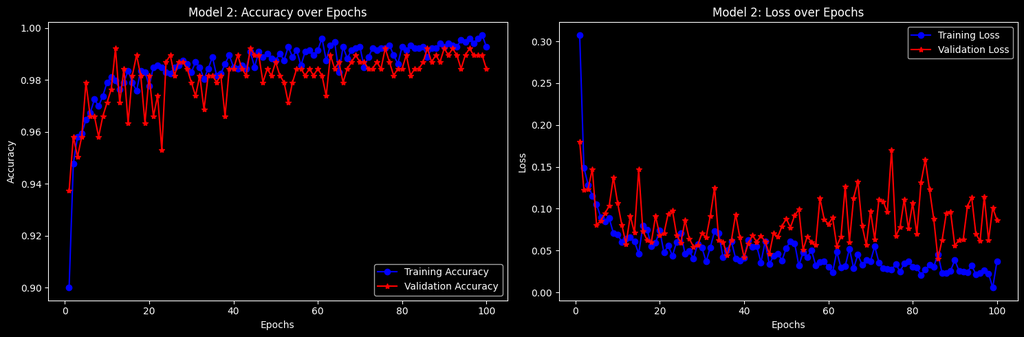

```
15/15 ━━━━━━━━━━━━━━━━━━━━ 0s 7ms/step

Model 2 Accuracy on Test Data: 0.98

Classification Report for Model 2:
              precision    recall  f1-score   support

         Low       1.00      0.98      0.99       249
      Medium       0.96      1.00      0.98       214
        High       1.00      0.62      0.77        16

    accuracy                           0.98       479
   macro avg       0.99      0.87      0.91       479
weighted avg       0.98      0.98      0.98       479

Confusion Matrix for Model 2:
[[245   4   0]
 [  0 214   0]
 [  0   6  10]]
```

```python
X = data.drop(columns=['Profile'])
y = data['Profile']

X_train, X_test, y_train, y_test = train_test_split(X, y, test_size=0.2, random_state=42)
X_train = scaler.fit_transform(X_train)
X_test = scaler.transform(X_test)

model_2 = Sequential()
model_2.add(Dense(128, input_dim=X_train.shape[1], activation='relu'))
model_2.add(Dropout(0.3))
model_2.add(Dense(64, activation='relu'))
model_2.add(Dense(32, activation='relu'))
model_2.add(Dense(3, activation='softmax'))

model_2.compile(optimizer='rmsprop', loss='sparse_categorical_crossentropy', metrics=['accuracy'])
history_2 = model_2.fit(X_train, y_train, epochs=100, batch_size=5, validation_split=0.2)

history_dict_2 = history_2.history
accuracy_2 = history_dict_2['accuracy']
val_accuracy_2 = history_dict_2['val_accuracy']
loss_2 = history_dict_2['loss']
val_loss_2 = history_dict_2['val_loss']
epochs_2 = range(1, len(accuracy_2) + 1)

fig, (ax1, ax2) = plt.subplots(1, 2, figsize=(15, 5))
ax1.plot(epochs_2, accuracy_2, 'bo-', label='Training Accuracy')
ax1.plot(epochs_2, val_accuracy_2, 'r*-', label='Validation Accuracy')
ax1.set_title('Model 2: Accuracy over Epochs')
ax1.set_xlabel('Epochs')
ax1.set_ylabel('Accuracy')
ax1.legend()

ax2.plot(epochs_2, loss_2, 'bo-', label='Training Loss')
ax2.plot(epochs_2, val_loss_2, 'r*-', label='Validation Loss')
ax2.set_title('Model 2: Loss over Epochs')
ax2.set_xlabel('Epochs')
ax2.set_ylabel('Loss')
ax2.legend()

plt.tight_layout()
plt.show()

predictions_2 = model_2.predict(X_test)
predicted_classes_2 = np.argmax(predictions_2, axis=1)

accuracy_2_test = accuracy_score(y_test, predicted_classes_2)
print(f"\nModel 2 Accuracy on Test Data: {accuracy_2_test:.2f}")
print("\nClassification Report for Model 2:")
print(classification_report(y_test, predicted_classes_2, target_names=['Low', 'Medium', 'High']))
print("Confusion Matrix for Model 2:")
print(confusion_matrix(y_test, predicted_classes_2))
```

#### Model 3:

- Changes:
  - Dataset Data Engineering
  - Model Definition
  - Model Compile
  - Model Training

```
77/77 ━━━━━━━━━━━━━━━━━━━━ 1s 6ms/step - accuracy: 0.3508 - loss: 1.0899 - val_accuracy: 0.5326 - val_loss: 1.0391
77/77 ━━━━━━━━━━━━━━━━━━━━ 0s 3ms/step - accuracy: 0.5172 - loss: 1.0082 - val_accuracy: 0.5483 - val_loss: 0.9710
77/77 ━━━━━━━━━━━━━━━━━━━━ 0s 3ms/step - accuracy: 0.5965 - loss: 0.9342 - val_accuracy: 0.5352 - val_loss: 0.9201
77/77 ━━━━━━━━━━━━━━━━━━━━ 0s 3ms/step - accuracy: 0.6022 - loss: 0.8939 - val_accuracy: 0.5352 - val_loss: 0.8787
77/77 ━━━━━━━━━━━━━━━━━━━━ 0s 3ms/step - accuracy: 0.6042 - loss: 0.8605 - val_accuracy: 0.5509 - val_loss: 0.8441
77/77 ━━━━━━━━━━━━━━━━━━━━ 0s 3ms/step - accuracy: 0.5993 - loss: 0.8435 - val_accuracy: 0.5822 - val_loss: 0.8140
77/77 ━━━━━━━━━━━━━━━━━━━━ 0s 3ms/step - accuracy: 0.6463 - loss: 0.7965 - val_accuracy: 0.6214 - val_loss: 0.7873
77/77 ━━━━━━━━━━━━━━━━━━━━ 0s 3ms/step - accuracy: 0.6584 - loss: 0.7832 - val_accuracy: 0.6527 - val_loss: 0.7638
77/77 ━━━━━━━━━━━━━━━━━━━━ 0s 4ms/step - accuracy: 0.6595 - loss: 0.7631 - val_accuracy: 0.6997 - val_loss: 0.7404
77/77 ━━━━━━━━━━━━━━━━━━━━ 0s 3ms/step - accuracy: 0.6681 - loss: 0.7465 - val_accuracy: 0.7520 - val_loss: 0.7197
77/77 ━━━━━━━━━━━━━━━━━━━━ 0s 3ms/step - accuracy: 0.6717 - loss: 0.7455 - val_accuracy: 0.7728 - val_loss: 0.7011
77/77 ━━━━━━━━━━━━━━━━━━━━ 0s 3ms/step - accuracy: 0.6920 - loss: 0.7259 - val_accuracy: 0.7807 - val_loss: 0.6817
77/77 ━━━━━━━━━━━━━━━━━━━━ 0s 4ms/step - accuracy: 0.7052 - loss: 0.6842 - val_accuracy: 0.7885 - val_loss: 0.6626
77/77 ━━━━━━━━━━━━━━━━━━━━ 0s 3ms/step - accuracy: 0.7192 - loss: 0.7045 - val_accuracy: 0.7963 - val_loss: 0.6458
77/77 ━━━━━━━━━━━━━━━━━━━━ 0s 3ms/step - accuracy: 0.7375 - loss: 0.6681 - val_accuracy: 0.7990 - val_loss: 0.6309
77/77 ━━━━━━━━━━━━━━━━━━━━ 0s 3ms/step - accuracy: 0.7517 - loss: 0.6857 - val_accuracy: 0.8068 - val_loss: 0.6172
77/77 ━━━━━━━━━━━━━━━━━━━━ 0s 3ms/step - accuracy: 0.7449 - loss: 0.6737 - val_accuracy: 0.8172 - val_loss: 0.6039
77/77 ━━━━━━━━━━━━━━━━━━━━ 0s 3ms/step - accuracy: 0.7593 - loss: 0.6366 - val_accuracy: 0.8198 - val_loss: 0.5897
77/77 ━━━━━━━━━━━━━━━━━━━━ 0s 3ms/step - accuracy: 0.7550 - loss: 0.6314 - val_accuracy: 0.8251 - val_loss: 0.5770
77/77 ━━━━━━━━━━━━━━━━━━━━ 0s 3ms/step - accuracy: 0.7578 - loss: 0.6287 - val_accuracy: 0.8225 - val_loss: 0.5642
77/77 ━━━━━━━━━━━━━━━━━━━━ 0s 3ms/step - accuracy: 0.7773 - loss: 0.5951 - val_accuracy: 0.8251 - val_loss: 0.5537
77/77 ━━━━━━━━━━━━━━━━━━━━ 0s 3ms/step - accuracy: 0.7841 - loss: 0.5838 - val_accuracy: 0.8277 - val_loss: 0.5431
77/77 ━━━━━━━━━━━━━━━━━━━━ 0s 3ms/step - accuracy: 0.7845 - loss: 0.5997 - val_accuracy: 0.8251 - val_loss: 0.5338
77/77 ━━━━━━━━━━━━━━━━━━━━ 0s 3ms/step - accuracy: 0.7959 - loss: 0.5663 - val_accuracy: 0.8277 - val_loss: 0.5250
77/77 ━━━━━━━━━━━━━━━━━━━━ 0s 3ms/step - accuracy: 0.7898 - loss: 0.5720 - val_accuracy: 0.8277 - val_loss: 0.5175
77/77 ━━━━━━━━━━━━━━━━━━━━ 0s 3ms/step - accuracy: 0.7682 - loss: 0.5885 - val_accuracy: 0.8303 - val_loss: 0.5109
77/77 ━━━━━━━━━━━━━━━━━━━━ 0s 3ms/step - accuracy: 0.8179 - loss: 0.5400 - val_accuracy: 0.8277 - val_loss: 0.5032
77/77 ━━━━━━━━━━━━━━━━━━━━ 0s 3ms/step - accuracy: 0.7899 - loss: 0.5468 - val_accuracy: 0.8303 - val_loss: 0.4963
77/77 ━━━━━━━━━━━━━━━━━━━━ 0s 3ms/step - accuracy: 0.7824 - loss: 0.5672 - val_accuracy: 0.8329 - val_loss: 0.4901
77/77 ━━━━━━━━━━━━━━━━━━━━ 0s 4ms/step - accuracy: 0.8110 - loss: 0.5255 - val_accuracy: 0.8329 - val_loss: 0.4846
77/77 ━━━━━━━━━━━━━━━━━━━━ 1s 4ms/step - accuracy: 0.8101 - loss: 0.5216 - val_accuracy: 0.8355 - val_loss: 0.4785
77/77 ━━━━━━━━━━━━━━━━━━━━ 1s 4ms/step - accuracy: 0.7791 - loss: 0.5456 - val_accuracy: 0.8381 - val_loss: 0.4742
77/77 ━━━━━━━━━━━━━━━━━━━━ 0s 4ms/step - accuracy: 0.8243 - loss: 0.5166 - val_accuracy: 0.8407 - val_loss: 0.4693
77/77 ━━━━━━━━━━━━━━━━━━━━ 1s 4ms/step - accuracy: 0.8008 - loss: 0.5131 - val_accuracy: 0.8407 - val_loss: 0.4641
77/77 ━━━━━━━━━━━━━━━━━━━━ 1s 4ms/step - accuracy: 0.8316 - loss: 0.5028 - val_accuracy: 0.8460 - val_loss: 0.4595
77/77 ━━━━━━━━━━━━━━━━━━━━ 0s 3ms/step - accuracy: 0.8102 - loss: 0.5158 - val_accuracy: 0.8512 - val_loss: 0.4551
77/77 ━━━━━━━━━━━━━━━━━━━━ 0s 3ms/step - accuracy: 0.8048 - loss: 0.5134 - val_accuracy: 0.8512 - val_loss: 0.4512
77/77 ━━━━━━━━━━━━━━━━━━━━ 0s 3ms/step - accuracy: 0.8220 - loss: 0.4931 - val_accuracy: 0.8538 - val_loss: 0.4473
77/77 ━━━━━━━━━━━━━━━━━━━━ 0s 3ms/step - accuracy: 0.8313 - loss: 0.4791 - val_accuracy: 0.8564 - val_loss: 0.4435
77/77 ━━━━━━━━━━━━━━━━━━━━ 0s 3ms/step - accuracy: 0.8477 - loss: 0.4660 - val_accuracy: 0.8564 - val_loss: 0.4393
```

[output cut: 45 more lines]

```
77/77 ━━━━━━━━━━━━━━━━━━━━ 0s 3ms/step - accuracy: 0.8806 - loss: 0.3579 - val_accuracy: 0.8747 - val_loss: 0.3468
77/77 ━━━━━━━━━━━━━━━━━━━━ 0s 3ms/step - accuracy: 0.8734 - loss: 0.3950 - val_accuracy: 0.8747 - val_loss: 0.3455
77/77 ━━━━━━━━━━━━━━━━━━━━ 0s 3ms/step - accuracy: 0.8630 - loss: 0.3876 - val_accuracy: 0.8747 - val_loss: 0.3443
77/77 ━━━━━━━━━━━━━━━━━━━━ 0s 3ms/step - accuracy: 0.8703 - loss: 0.3922 - val_accuracy: 0.8747 - val_loss: 0.3432
77/77 ━━━━━━━━━━━━━━━━━━━━ 0s 3ms/step - accuracy: 0.8731 - loss: 0.3773 - val_accuracy: 0.8747 - val_loss: 0.3421
77/77 ━━━━━━━━━━━━━━━━━━━━ 0s 3ms/step - accuracy: 0.8556 - loss: 0.3934 - val_accuracy: 0.8747 - val_loss: 0.3410
77/77 ━━━━━━━━━━━━━━━━━━━━ 0s 3ms/step - accuracy: 0.8572 - loss: 0.3839 - val_accuracy: 0.8747 - val_loss: 0.3400
77/77 ━━━━━━━━━━━━━━━━━━━━ 0s 3ms/step - accuracy: 0.8622 - loss: 0.3941 - val_accuracy: 0.8747 - val_loss: 0.3388
77/77 ━━━━━━━━━━━━━━━━━━━━ 0s 3ms/step - accuracy: 0.8603 - loss: 0.3778 - val_accuracy: 0.8747 - val_loss: 0.3378
77/77 ━━━━━━━━━━━━━━━━━━━━ 0s 3ms/step - accuracy: 0.8835 - loss: 0.3483 - val_accuracy: 0.8747 - val_loss: 0.3367
77/77 ━━━━━━━━━━━━━━━━━━━━ 0s 3ms/step - accuracy: 0.8523 - loss: 0.3924 - val_accuracy: 0.8773 - val_loss: 0.3360
77/77 ━━━━━━━━━━━━━━━━━━━━ 0s 3ms/step - accuracy: 0.8763 - loss: 0.3496 - val_accuracy: 0.8773 - val_loss: 0.3347
77/77 ━━━━━━━━━━━━━━━━━━━━ 0s 3ms/step - accuracy: 0.8835 - loss: 0.3682 - val_accuracy: 0.8773 - val_loss: 0.3336
77/77 ━━━━━━━━━━━━━━━━━━━━ 0s 3ms/step - accuracy: 0.8664 - loss: 0.3722 - val_accuracy: 0.8773 - val_loss: 0.3326
77/77 ━━━━━━━━━━━━━━━━━━━━ 0s 3ms/step - accuracy: 0.8600 - loss: 0.3916 - val_accuracy: 0.8747 - val_loss: 0.3316
```

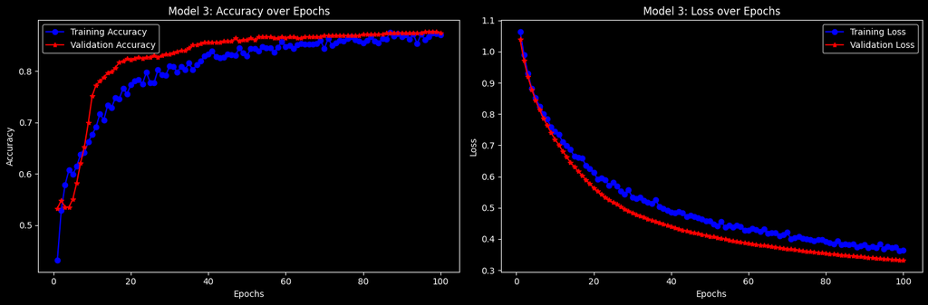

```
15/15 ━━━━━━━━━━━━━━━━━━━━ 0s 6ms/step

Model 3 Accuracy on Test Data: 0.89

Classification Report for Model 3:
              precision    recall  f1-score   support

         Low       0.91      0.94      0.93       249
      Medium       0.86      0.90      0.88       214
        High       0.00      0.00      0.00        16

    accuracy                           0.89       479
   macro avg       0.59      0.61      0.60       479
weighted avg       0.86      0.89      0.87       479

Confusion Matrix for Model 3:
[[234  15   0]
 [ 22 192   0]
 [  0  16   0]]
```

```python
X = data.drop(columns=['Profile'])
y = data['Profile']

X_train, X_test, y_train, y_test = train_test_split(X, y, test_size=0.2, random_state=42)
X_train = scaler.fit_transform(X_train)
X_test = scaler.transform(X_test)
X_train = np.expand_dims(X_train, axis=2)
X_test = np.expand_dims(X_test, axis=2)

model_3 = Sequential()
model_3.add(Conv1D(filters=64, kernel_size=3, activation='relu', input_shape=(X_train.shape[1], 1)))
model_3.add(MaxPooling1D(pool_size=2))
model_3.add(Flatten())
model_3.add(Dense(64, activation='relu'))
model_3.add(Dropout(0.4))
model_3.add(Dense(32, activation='relu'))
model_3.add(Dense(3, activation='softmax'))

model_3.compile(optimizer='adagrad', loss='sparse_categorical_crossentropy', metrics=['accuracy'])
history_3 = model_3.fit(X_train, y_train, epochs=100, batch_size=20, validation_split=0.2)

history_dict_3 = history_3.history
accuracy_3 = history_dict_3['accuracy']
val_accuracy_3 = history_dict_3['val_accuracy']
loss_3 = history_dict_3['loss']
val_loss_3 = history_dict_3['val_loss']
epochs_3 = range(1, len(accuracy_3) + 1)

fig, (ax1, ax2) = plt.subplots(1, 2, figsize=(15, 5))
ax1.plot(epochs_3, accuracy_3, 'bo-', label='Training Accuracy')
ax1.plot(epochs_3, val_accuracy_3, 'r*-', label='Validation Accuracy')
ax1.set_title('Model 3: Accuracy over Epochs')
ax1.set_xlabel('Epochs')
ax1.set_ylabel('Accuracy')
ax1.legend()

ax2.plot(epochs_3, loss_3, 'bo-', label='Training Loss')
ax2.plot(epochs_3, val_loss_3, 'r*-', label='Validation Loss')
ax2.set_title('Model 3: Loss over Epochs')
ax2.set_xlabel('Epochs')
ax2.set_ylabel('Loss')
ax2.legend()

plt.tight_layout()
plt.show()

predictions_3 = model_3.predict(X_test)
predicted_classes_3 = np.argmax(predictions_3, axis=1)

accuracy_3_test = accuracy_score(y_test, predicted_classes_3)
print(f"\nModel 3 Accuracy on Test Data: {accuracy_3_test:.2f}")
print("\nClassification Report for Model 3:")
print(classification_report(y_test, predicted_classes_3, target_names=['Low', 'Medium', 'High']))
print("Confusion Matrix for Model 3:")
print(confusion_matrix(y_test, predicted_classes_3))
```

| Modelo | Accuracy Score |
| --- | --- |
| Modelo 1 | 0.98 |
| Modelo 2 | 0.98 |
| Modelo 3 | 0.89 |